# mixed models in R

11 May 2016

## Acknowledgments

- `lme4`: Doug Bates, Martin Mächler, Steve Walker
- Data: Josh Banta, Adrian Stier, Sea McKeon, David Julian, Jada-Simone White
- \($\): NSERC (Discovery), SHARCnet

## Examples and definitions

## (Generalized) linear mixed models

(G)LMMs: a statistical modeling framework incorporating:

- combinations of categorical and continuous predictors,  
  and interactions
- (some) non-Normal responses  
  (e.g. binomial, Poisson, and extensions)
- (some) nonlinearity  
  (e.g. logistic, exponential, hyperbolic)
- non-independent (grouped) data

## Coral predation (McKeon et al. 2012)

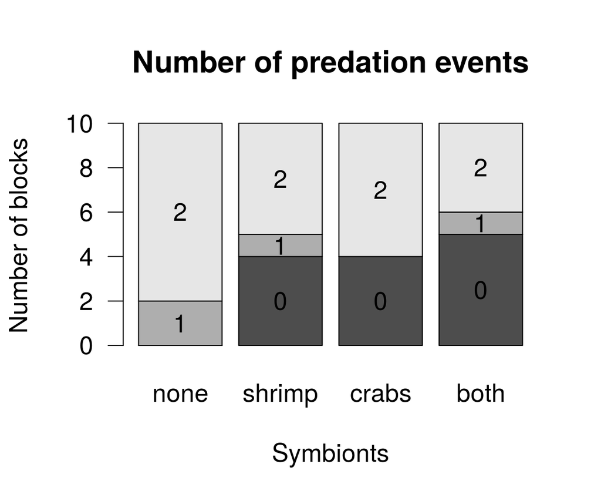

## *Glycera* cell survival (D. Julian unpubl.)

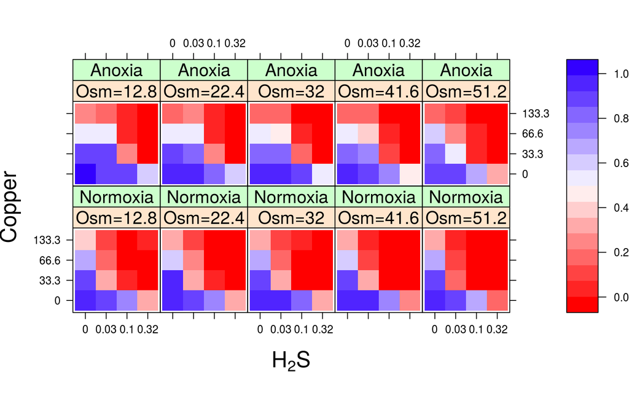

## Plant response to fertilization & herbivory (Banta et al. 2010)

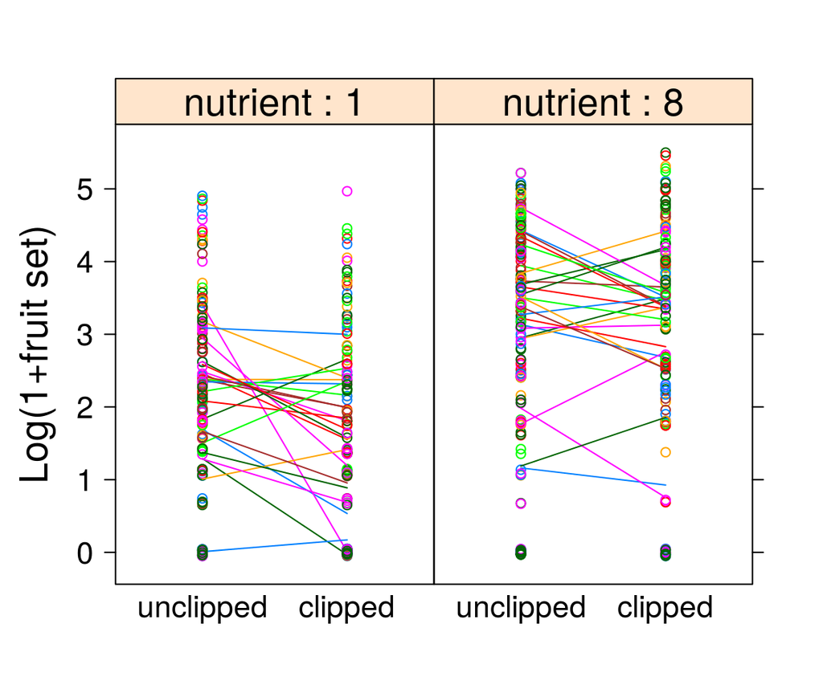

## Technical definition

\[ \begin{split} \underbrace{Y_i}_{\text{response}} & \sim \overbrace{\text{Distr}}^{\substack{\text{conditional} \\ \text{distribution}}}(\underbrace{g^{-1}(\eta_i)}_{\substack{\text{inverse} \\ \text{link} \\ \text{function}}},\underbrace{\phi}_{\substack{\text{scale} \\ \text{parameter}}}) \\ \underbrace{{\boldsymbol \eta}}_{\substack{\text{linear} \\ \text{predictor}}} & = \underbrace{{\boldsymbol X}{\boldsymbol \beta}}_{\substack{\text{fixed} \\ \text{effects}}} + \underbrace{{\boldsymbol Z}{\boldsymbol b}}_{\substack{\text{random} \\ \text{effects}}} \\ \underbrace{{\boldsymbol b}}_{\substack{\text{conditional} \\ \text{modes}}} & \sim \text{MVN}({\boldsymbol 0},\underbrace{\Sigma({\boldsymbol \theta})}_{\substack{\text{variance-} \\ \text{covariance} \\ \text{matrix}}}) \end{split} \]

## What are random effects?

A method for …

- accounting for among-individual, within-block correlation
- compromising between
  - **complete pooling** (no among-block variance)
  - **fixed effects** (large among-block variance)
- handling levels selected at random from a larger population
- sharing information among levels (*shrinkage estimation*)
- estimating variability among levels
- allowing predictions for unmeasured levels

## Random-effect myths

- levels of random effects must always be sampled at random
- a complete sample cannot be treated as a random effect
- random effects are always a *nuisance variable*
- you can't say anything about the predictions of a random effect
- you should always use a random effect no matter how few levels you have

## Estimation

## Maximum likelihood estimation

- Best fit is a compromise between two components  
  (consistency of data with fixed effects and conditional modes; consistency of random effect with RE distribution)
- Goodness-of-fit *integrates* over conditional modes

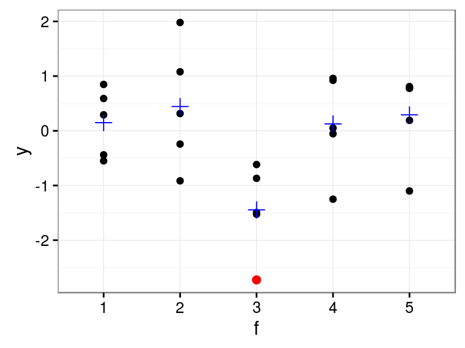

## Shrinkage: conditional modes

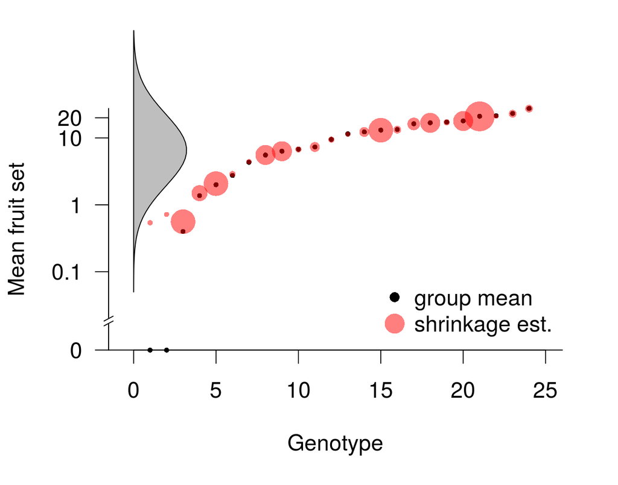

## Estimation methods

- *deterministic*: various approximate integrals (Breslow 2004)
  - Penalized quasi-likelihood, Laplace, Gauss-Hermite quadrature (Biswas 2015)  
    best methods needed for large variance, small clusters
  - flexibility and speed vs. accuracy
- *stochastic* (Monte Carlo): frequentist and Bayesian (Booth et al. 1999,Sung et al. (2007),Ponciano et al. (2009))
  - usually slower, more finicky, but flexible and accurate

## Estimation: coral example

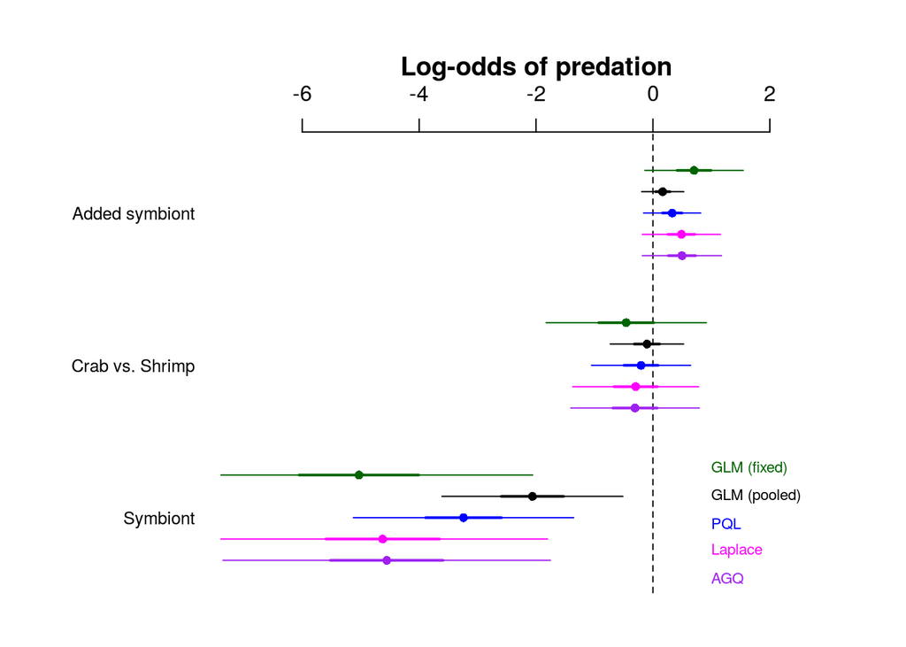

## Inference

## Wald tests

- typical results of `summary()`
- exact for ANOVA, regression:  
  approximation for GLM(M)s
- fast
- approximation is sometimes awful (*Hauck-Donner effect*)

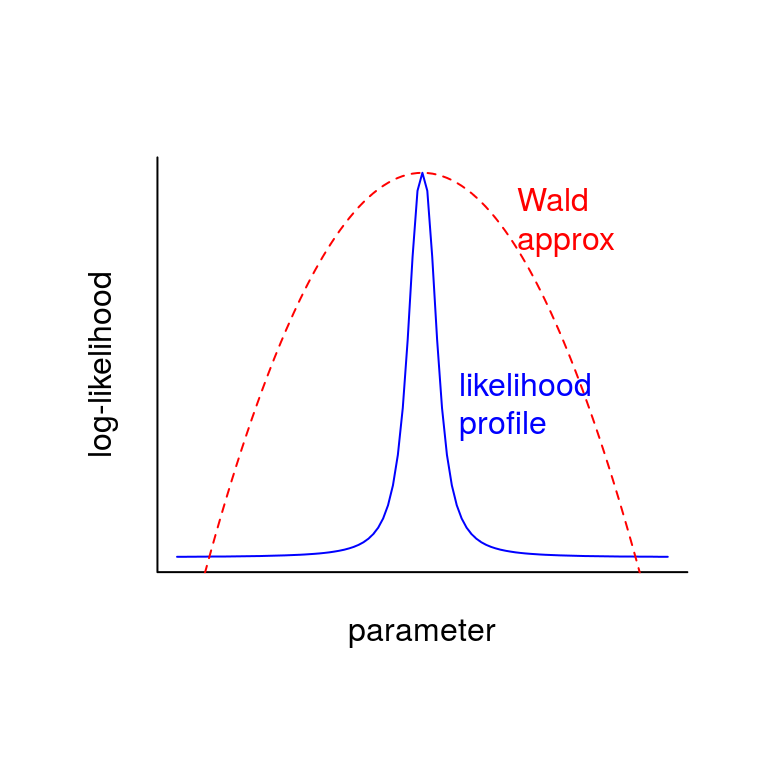

## Likelihood ratio tests

- better than Wald, but still have two problems:
  - "denominator degrees of freedom'' (when estimating scale parameter)
  - for GLMMs, distributions are approximate anyway (Bartlett corrections)
  - Kenward-Roger correction? (Stroup 2014)
- Profile confidence intervals: expensive/fragile

## Parametric bootstrapping

- fit null model to data
- simulate "data" from null model
- fit null and working model, compute likelihood difference
- repeat to estimate null distribution
- should be OK but ??? not well tested  
  (assumes estimated parameters are "sufficiently" good)

## Bayesian inference

- If we have a good sample from the posterior distribution (Markov chains have converged etc.) we get most of the inferences we want for free by summarizing the marginal posteriors
- *post hoc* Bayesian methods: use deterministic/frequentist methods to find the maximum, then sample around it

## Confidence intervals

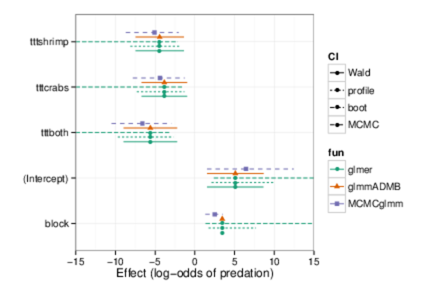

## formula formats

- `fixed`: fixed-effect formula
- `random`: random-effect formula (in `lme4`, combined with fixed)
  - simplest: `1|g`, single intercept term
  - nested: `1|g1/g2`
  - random-slopes: `x|g`
  - independent terms: `(1|g)+(x+0|g)` or `(x||g)`
- `lme`: `weights`, `correlation` for heteroscedasticity and residual correlation
- `MCMCglmm`: options for variance structure

## On beyond `lme4`

- basic
  - `nlme` (`lme`)
  - `MCMCglmm`
  - inference/tests: `lmerTest`, `afex`, `pbkrtest`  
    (`car`, `lsmeans`, `effects`, `multcomp`)
  - `blme` (Bayesian regularization)
  - `gamm4` (additive models)
  - pretty output: `broom`, `dotwhisker`, `pixiedust`
- advanced/specialized
  - `glmmADMB`, `glmmTMB`: zero-inflated and other distributions
  - `brms`, `rstanarm`: interfaces to Stan
  - `INLA`: spatial and temporal correlations

## Challenges & open questions

## On beyond R

- Julia: MixedModels package
- SAS: PROC MIXED, NLMIXED
- AS-REML
- Stata (GLLAMM, xtmelogit)
- AD Model Builder; Template Model Builder
- HLM, MLWiN
- MCMC: JAGS, Stan, [rethinking package](https://github.com/rmcelreath/rethinking)

[figure not shown]

## Challenges

- Small clusters: need AGQ/MCMC
- Small numbers of clusters: need finite-size corrections  
  (Kenward-Roger/parametric bootstrap/MCMC)
- Simpler inference: importance sampling, quantiles, MCMC?
- Small data sets: issues with *singular* fits  
  Barr et al. (2013) vs. Bates et al. (2015)
- Big data: speed, storage, parallelization
- Model diagnosis
- Confidence intervals accounting for uncertainty in variances

See also: [ecostats chapter example](https://rawgit.com/bbolker/mixedmodels-misc/master/ecostats_chap.html%5D); [NCEAS modeling examples](https://groups.nceas.ucsb.edu/non-linear-modeling/projects); [BMB mixed models repo](https://github.com/bbolker/mixedmodels-misc), including [GLMM FAQ](https://rawgit.com/bbolker/mixedmodels-misc/master/glmmFAQ.html)

## Spatial and temporal correlations

- Sometimes blocking takes care of non-independence …
- but sometimes there is temporal or spatial correlation *within* blocks
- … also phylogenetic … (Ives et al. 2006)
- "G-side" vs. "R-side" effects
- tricky to implement for GLMMs,  
  but new possibilities on the horizon (Rue et al. 2009; Rousset et al. 2014) (`INLA`, `spaMM`); [lme4ord package](https://github.com/stevencarlislewalker/lme4ord)
- CAR, SAR, Moran eigenvectors … ?
- additive models?

## Next steps

- Complex random effects:  
  regularization, model selection, penalized methods (lasso/fence)
- Flexible correlation and variance structures
- Flexible/nonparametric random effects distributions
- hybrid & improved MCMC methods
- *Reliable* assessment of out-of-sample performance

## Sales pitch

- `http://ms.mcmaster.ca/~bolker/misc/private/14-Fox-Chap13.pdf`
- [supplementary material](https://rawgit.com/bbolker/mixedmodels-misc/master/ecostats_chap.html%60)
- B. M. Bolker (2015)

[figure not shown]

  (code ASPROMP8)

## References

Banta, JA et al. 2010. *Oikos* 119 (2) (February): 359–369. doi:10.1111/j.1600-0706.2009.17726.x. http://onlinelibrary.wiley.com/doi/10.1111/j.1600-0706.2009.17726.x/abstract.

Barr, DJ et al. 2013. *Journal of Memory and Language* 68 (3) (April): 255–278. doi:10.1016/j.jml.2012.11.001. http://www.sciencedirect.com/science/article/pii/S0749596X12001180.

Bates, D et al. 2015. *arXiv:1506.04967 [stat]* (June). http://arxiv.org/abs/1506.04967.

Biswas, K. 2015. Master’s thesis, McMaster University. https://macsphere.mcmaster.ca/bitstream/11375/17272/2/M.Sc_Thesis_final_Keya_Biswas.pdf.

Bolker, BM. 2015. In *Ecological statistics: Contemporary theory and application*, ed by. Gordon A. Fox et al. Oxford University Press.

Booth, JG et al. 1999. *Journal of the Royal Statistical Society. Series B* 61 (1): 265–285. doi:10.1111/1467-9868.00176.

Breslow, NE. 2004. In *Proceedings of the second seattle symposium in biostatistics: Analysis of correlated data*, ed by. Danyu Y. Lin et al., 1–22. Springer.

Ives, AR et al. 2006. *Ecological Applications* 16 (1): 20–32. http://www.esajournals.org/doi/pdf/10.1890/04-0702.

McKeon, CS et al. 2012. *Oecologia* 169 (4): 1095–1103. doi:10.1007/s00442-012-2275-2.

Ponciano, JM et al. 2009. *Ecology* 90 (2) (February): 356–362. http://www.jstor.org/stable/27650990.

Rousset, F et al. 2014. *Ecography*: no–no. doi:10.1111/ecog.00566. http://onlinelibrary.wiley.com/doi/10.1111/ecog.00566/abstract.

Rue, H et al. 2009. *Journal of the Royal Statistical Society, Series B* 71 (2): 319–392.

Stroup, WW. 2014. *Agronomy Journal* 106: 1–17. doi:10.2134/agronj2013.0342. https://dl.sciencesocieties.org/publications/aj/articles/0/0/agronj2013.0342.

Sung, YJ et al. 2007. *The Annals of Statistics* 35 (3) (July): 990–1011. doi:10.1214/009053606000001389. http://projecteuclid.org/euclid.aos/1185303995.